# Data Visualization : In-class Materials

Nabiilah Ardini Fauziyyah

March 25, 2021

# The Flow

1. Start with Business Question
2. Prepare the data
3. Visualize your data

# The State of Trending Videos

Kita adalah seorang *YouTuber* yang ingin meningkatkan pamor dari channel YouTube kita. Kita berencana untuk membuat konten video yang dapat menjadi trending sehingga dapat meningkatkan popularitas channel. Hari ini, Kita baru saja mendapatkan data **YouTube’s US Trending Videos** dan akhirnya ingin mencari tahu, **apa saja yang membuat suatu video menjadi trending**?

## Read Data

```r
vids <- read.csv("USvideos.csv")
```

cek data:

```r
head(vids)
```

|  | trending_date | title | channel_title | category_id | publish_time | views | likes | dislikes | comment_count | comments_disabled | ratings_disabled | video_error_or_removed |
| --- | --- | --- | --- | --- | --- | --- | --- | --- | --- | --- | --- | --- |
| 1 | 17.14.11 | WE WANT TO TALK ABOUT OUR MARRIAGE | CaseyNeistat | 22 | 2017-11-13T17:13:01.000Z | 748374 | 57527 | 2966 | 15954 | FALSE | FALSE | FALSE |
| 2 | 17.14.11 | The Trump Presidency: Last Week Tonight with John Oliver (HBO) | LastWeekTonight | 24 | 2017-11-13T07:30:00.000Z | 2418783 | 97185 | 6146 | 12703 | FALSE | FALSE | FALSE |
| 3 | 17.14.11 | Racist Superman \| Rudy Mancuso, King Bach & Lele Pons | Rudy Mancuso | 23 | 2017-11-12T19:05:24.000Z | 3191434 | 146033 | 5339 | 8181 | FALSE | FALSE | FALSE |
| 4 | 17.14.11 | Nickelback Lyrics: Real or Fake? | Good Mythical Morning | 24 | 2017-11-13T11:00:04.000Z | 343168 | 10172 | 666 | 2146 | FALSE | FALSE | FALSE |
| 5 | 17.14.11 | I Dare You: GOING BALD!? | nigahiga | 24 | 2017-11-12T18:01:41.000Z | 2095731 | 132235 | 1989 | 17518 | FALSE | FALSE | FALSE |
| 6 | 17.14.11 | 2 Weeks with iPhone X | iJustine | 28 | 2017-11-13T19:07:23.000Z | 119180 | 9763 | 511 | 1434 | FALSE | FALSE | FALSE |

YouTube’s US Trending Videos adalah kumpulan 200 video trending di US per harinya sejak 2017-11-14 hingga 2018-01-21. Berikut adalah deskripsi kolomnya:

- **trending_date**: tanggal trending
- **title**: judul video
- **channel_title**: nama channel Youtube
- **category_id**: kategori video
- **publish_time**: tanggal upload video
- **views**: jumlah views
- **likes**: jumlah likes
- **dislikes**: jumlah dislikes
- **comment_count**: jumlah komentar
- **comment_disabled**: apakah kolom komentar tidak diaktifkan
- **rating_disabled**: apakah rating video tidak diaktifkan
- **video_error_or_removed**: apakah video dihapus

Eksplor data anda! Apakah tiap kolom sudah memiliki tipe data yang tepat?

1. trending_date, publish_time -> date
2. category_id -> factor berisi label kategori seharusnya

## Data Wrangling

Data wrangling adalah istilah lain dari **data cleaning**. Beberapa contohnya telah kita pelajari di kelas *Programming for Data Science*, seperti mengubah tipe data dan subsetting baris/kolom tertentu.

### `lubridate`

**lubridate** adalah package yang sangat powerful untuk mengolah data waktu dan tanggal.

Sebelumnya kita mengubah data ke tipe date dengan menggunakan `as.Date()`:

YEAR  
%Y = YYYY  
%y = YY

MONTH  
%B = month name e.g. March  
%b = month name(abbreviation) e.g. Mar  
%m = 2 digits mo e.g. 03  
%M = 1 digit mo e.g. 3

DAY  
%A = weekday e.g. Friday  
%d = weekday digit.

ubah `trending_date` menjadi tipe data date:

```r
vids$trending_date[1]
```

```
#> [1] "17.14.11"
```

Note: kita tidak harus mencantumkan nama parameter fungsi, asalkan urutan parameternya sesuai default.

```r
base_date <- as.Date(x =vids$trending_date, format = "%y.%d.%m")
head(base_date)
```

```
#> [1] "2017-11-14" "2017-11-14" "2017-11-14" "2017-11-14" "2017-11-14"
#> [6] "2017-11-14"
```

menggunakan lubridate:

```r
library(lubridate)
```

```r
a <- "22/03/21"
b <- "22-March-2021"
c <- "Monday, 22-03-2021"
d <- "2021/03/22, 1:42PM"
```

```r
# metode base
as.Date(a, "%d/%m/%y")
```

```
#> [1] "2021-03-22"
```

```r
# metode lubridate: masukan urutan d/m/y nya saja
dmy(a)
```

```
#> [1] "2021-03-22"
```

```r
dmy(b)
```

```
#> [1] "2021-03-22"
```

```r
dmy(c)
```

```
#> [1] "2021-03-22"
```

```r
ymd_hm(d)
```

```
#> [1] "2021-03-22 13:42:00 UTC"
```

idealnya dalam 1 kolom punya format data yang sama. kalau ada kejadian ini, kita harus seleksi manual mana data yang formatnya berbeda, kemudian kita samakan dulu formatnya dengan data yang lain, baru diubah ke tipe date. -> tantangan dalam data wrangling

**Dive Deeper**:

1. Ubah kolom `trending_date` menjadi tipe date dengan fungsi dari package lubridate!

```r
head(vids)
```

|  | trending_date | title | channel_title | category_id | publish_time | views | likes | dislikes | comment_count | comments_disabled | ratings_disabled | video_error_or_removed |
| --- | --- | --- | --- | --- | --- | --- | --- | --- | --- | --- | --- | --- |
| 1 | 17.14.11 | WE WANT TO TALK ABOUT OUR MARRIAGE | CaseyNeistat | 22 | 2017-11-13T17:13:01.000Z | 748374 | 57527 | 2966 | 15954 | FALSE | FALSE | FALSE |
| 2 | 17.14.11 | The Trump Presidency: Last Week Tonight with John Oliver (HBO) | LastWeekTonight | 24 | 2017-11-13T07:30:00.000Z | 2418783 | 97185 | 6146 | 12703 | FALSE | FALSE | FALSE |
| 3 | 17.14.11 | Racist Superman \| Rudy Mancuso, King Bach & Lele Pons | Rudy Mancuso | 23 | 2017-11-12T19:05:24.000Z | 3191434 | 146033 | 5339 | 8181 | FALSE | FALSE | FALSE |
| 4 | 17.14.11 | Nickelback Lyrics: Real or Fake? | Good Mythical Morning | 24 | 2017-11-13T11:00:04.000Z | 343168 | 10172 | 666 | 2146 | FALSE | FALSE | FALSE |
| 5 | 17.14.11 | I Dare You: GOING BALD!? | nigahiga | 24 | 2017-11-12T18:01:41.000Z | 2095731 | 132235 | 1989 | 17518 | FALSE | FALSE | FALSE |
| 6 | 17.14.11 | 2 Weeks with iPhone X | iJustine | 28 | 2017-11-13T19:07:23.000Z | 119180 | 9763 | 511 | 1434 | FALSE | FALSE | FALSE |

```r
vids$trending_date <- ydm(vids$trending_date)
head(vids)
```

|  | trending_date | title | channel_title | category_id | publish_time | views | likes | dislikes | comment_count | comments_disabled | ratings_disabled | video_error_or_removed |
| --- | --- | --- | --- | --- | --- | --- | --- | --- | --- | --- | --- | --- |
| 1 | 2017-11-14 | WE WANT TO TALK ABOUT OUR MARRIAGE | CaseyNeistat | 22 | 2017-11-13T17:13:01.000Z | 748374 | 57527 | 2966 | 15954 | FALSE | FALSE | FALSE |
| 2 | 2017-11-14 | The Trump Presidency: Last Week Tonight with John Oliver (HBO) | LastWeekTonight | 24 | 2017-11-13T07:30:00.000Z | 2418783 | 97185 | 6146 | 12703 | FALSE | FALSE | FALSE |
| 3 | 2017-11-14 | Racist Superman \| Rudy Mancuso, King Bach & Lele Pons | Rudy Mancuso | 23 | 2017-11-12T19:05:24.000Z | 3191434 | 146033 | 5339 | 8181 | FALSE | FALSE | FALSE |
| 4 | 2017-11-14 | Nickelback Lyrics: Real or Fake? | Good Mythical Morning | 24 | 2017-11-13T11:00:04.000Z | 343168 | 10172 | 666 | 2146 | FALSE | FALSE | FALSE |
| 5 | 2017-11-14 | I Dare You: GOING BALD!? | nigahiga | 24 | 2017-11-12T18:01:41.000Z | 2095731 | 132235 | 1989 | 17518 | FALSE | FALSE | FALSE |
| 6 | 2017-11-14 | 2 Weeks with iPhone X | iJustine | 28 | 2017-11-13T19:07:23.000Z | 119180 | 9763 | 511 | 1434 | FALSE | FALSE | FALSE |

2. Ubah kolom `publish_time` menjadi tipe date-time dengan fungsi dari package lubridate! Perhatikan informasi timezone!

Contoh:

```r
a <- ymd_hms(vids$publish_time) # ubah ke standard time UTC
a[1] # UTC
```

```
#> [1] "2017-11-13 17:13:01 UTC"
```

```r
b <- ymd_hms(vids$publish_time, tz = "Asia/Jakarta") # ubah dengan timezone
b[1] # UTC +7
```

```
#> [1] "2017-11-14 00:13:01 WIB"
```

Referensi timezone: https://en.wikipedia.org/wiki/List_of_tz_database_time_zones#List

```r
# your code here
vids$publish_time <- ymd_hms(vids$publish_time, tz = "America/New_York")
```

cek data:

```r
head(vids)
```

|  | trending_date | title | channel_title | category_id | publish_time | views | likes | dislikes | comment_count | comments_disabled | ratings_disabled | video_error_or_removed |
| --- | --- | --- | --- | --- | --- | --- | --- | --- | --- | --- | --- | --- |
| 1 | 2017-11-14 | WE WANT TO TALK ABOUT OUR MARRIAGE | CaseyNeistat | 22 | 2017-11-13 12:13:01 | 748374 | 57527 | 2966 | 15954 | FALSE | FALSE | FALSE |
| 2 | 2017-11-14 | The Trump Presidency: Last Week Tonight with John Oliver (HBO) | LastWeekTonight | 24 | 2017-11-13 02:30:00 | 2418783 | 97185 | 6146 | 12703 | FALSE | FALSE | FALSE |
| 3 | 2017-11-14 | Racist Superman \| Rudy Mancuso, King Bach & Lele Pons | Rudy Mancuso | 23 | 2017-11-12 14:05:24 | 3191434 | 146033 | 5339 | 8181 | FALSE | FALSE | FALSE |
| 4 | 2017-11-14 | Nickelback Lyrics: Real or Fake? | Good Mythical Morning | 24 | 2017-11-13 06:00:04 | 343168 | 10172 | 666 | 2146 | FALSE | FALSE | FALSE |
| 5 | 2017-11-14 | I Dare You: GOING BALD!? | nigahiga | 24 | 2017-11-12 13:01:41 | 2095731 | 132235 | 1989 | 17518 | FALSE | FALSE | FALSE |
| 6 | 2017-11-14 | 2 Weeks with iPhone X | iJustine | 28 | 2017-11-13 14:07:23 | 119180 | 9763 | 511 | 1434 | FALSE | FALSE | FALSE |

### `sapply()` & `lapply()`

**sapply**: mengaplikasikan fungsi ke tiap baris pada suatu kolom secara bersamaan.

formula: `sapply(data, fungsi)`

untuk mengubah suatu nilai dengan nilai tertentu dapat digunakan fungsi `switch()`. Namun switch hanya dapat mengubah satu nilai:

```r
switch("1",
       "1" = "Education",
       "2" = "Travel",
       "3" = "Music")
```

```
#> [1] "Education"
```

```r
# # will return error
# switch(c("1","2"),
#        "1" = "Education",
#        "2" = "Travel",
#        "3" = "Music")
```

Hal ini diatasi dengan `sapply()`:

```r
data <- c("1","2")

sapply(X = data, # data/kolom yang ingin diubah
       FUN = switch, # fungsi
       "1" = "Education",
       "2" = "Travel",
       "4" = "Music")
```

```
#>           1           2
#> "Education"    "Travel"
```

**Note:**

- `switch()` membutuhkan kamus untuk mentranslasikan nilai. Bila nilai tidak ada pada kamus, maka dihasilkan NULL.
- Nilai yang ditranslasi lebih baik diubah ke tipe karakter terlebih dahulu

Mengubah `category_id` untuk tiap row dengan `switch()` dengan bantuan `sapply()`:

```r
vids$category_id <- sapply(as.character(vids$category_id), switch,
                           "1" = "Film and Animation",
                           "2" = "Autos and Vehicles",
                           "10" = "Music",
                           "15" = "Pets and Animals",
                           "17" = "Sports",
                           "19" = "Travel and Events",
                           "20" = "Gaming",
                           "22" = "People and Blogs",
                           "23" = "Comedy",
                           "24" = "Entertainment",
                           "25" = "News and Politics",
                           "26" = "Howto and Style",
                           "27" = "Education",
                           "28" = "Science and Technology",
                           "29" = "Nonprofit and Activism",
                           "43" = "Shows")

vids$category_id <- as.factor(vids$category_id)
```

**lapply**: untuk mengaplikasikan fungsi (misal merubah tipe data) ke beberapa kolom secara bersamaan.

formula: `lapply(data, fungsi)`

*Note:* Di bawah adalah contoh penggunaan lapply(), namun pada kasus ini tidak wajib dilakukan.

```r
# cara base
vids$views <- as.numeric(vids$views)
vids$likes <- as.numeric(vids$likes)
vids$dislikes <- as.numeric(vids$dislikes)
vids$comment_count <- as.numeric(vids$comment_count)
```

```r
# cara `lapply()`
vids[,c("views", "likes", "dislikes", "comment_count")] <- lapply(vids[,c("views", "likes", "dislikes", "comment_count")], as.numeric)

str(vids)
```

```
#> 'data.frame':    13400 obs. of  12 variables:
#>  $ trending_date         : Date, format: "2017-11-14" "2017-11-14" ...
#>  $ title                 : chr  "WE WANT TO TALK ABOUT OUR MARRIAGE" "The Trump Presidency: Last Week Tonight with John Oliver (HBO)" "Racist Superman | Rudy Mancuso, King Bach & Lele Pons" "Nickelback Lyrics: Real or Fake?" ...
#>  $ channel_title         : chr  "CaseyNeistat" "LastWeekTonight" "Rudy Mancuso" "Good Mythical Morning" ...
#>  $ category_id           : Factor w/ 16 levels "Autos and Vehicles",..: 11 4 2 4 4 13 4 13 5 9 ...
#>  $ publish_time          : POSIXct, format: "2017-11-13 12:13:01" "2017-11-13 02:30:00" ...
#>  $ views                 : num  748374 2418783 3191434 343168 2095731 ...
#>  $ likes                 : num  57527 97185 146033 10172 132235 ...
#>  $ dislikes              : num  2966 6146 5339 666 1989 ...
#>  $ comment_count         : num  15954 12703 8181 2146 17518 ...
#>  $ comments_disabled     : logi  FALSE FALSE FALSE FALSE FALSE FALSE ...
#>  $ ratings_disabled      : logi  FALSE FALSE FALSE FALSE FALSE FALSE ...
#>  $ video_error_or_removed: logi  FALSE FALSE FALSE FALSE FALSE FALSE ...
```

### Feature Engineering

Feature engineering adalah membuat kolom/variabel baru berdasarkan data yang ada. Hal ini berguna untuk mengekstrak informasi tambahan yang bisa digunakan untuk eksplorasi data dan modeling.

1. Ekstrak jam publish time ke dalam kolom baru `publish_hour`

```r
vids$publish_hour <- hour(vids$publish_time)
head(vids)
```

|  | trending_date | title | channel_title | category_id | publish_time | views | likes | dislikes | comment_count | comments_disabled | ratings_disabled | video_error_or_removed | publish_hour |
| --- | --- | --- | --- | --- | --- | --- | --- | --- | --- | --- | --- | --- | --- |
| 1 | 2017-11-14 | WE WANT TO TALK ABOUT OUR MARRIAGE | CaseyNeistat | People and Blogs | 2017-11-13 12:13:01 | 748374 | 57527 | 2966 | 15954 | FALSE | FALSE | FALSE | 12 |
| 2 | 2017-11-14 | The Trump Presidency: Last Week Tonight with John Oliver (HBO) | LastWeekTonight | Entertainment | 2017-11-13 02:30:00 | 2418783 | 97185 | 6146 | 12703 | FALSE | FALSE | FALSE | 2 |
| 3 | 2017-11-14 | Racist Superman \| Rudy Mancuso, King Bach & Lele Pons | Rudy Mancuso | Comedy | 2017-11-12 14:05:24 | 3191434 | 146033 | 5339 | 8181 | FALSE | FALSE | FALSE | 14 |
| 4 | 2017-11-14 | Nickelback Lyrics: Real or Fake? | Good Mythical Morning | Entertainment | 2017-11-13 06:00:04 | 343168 | 10172 | 666 | 2146 | FALSE | FALSE | FALSE | 6 |
| 5 | 2017-11-14 | I Dare You: GOING BALD!? | nigahiga | Entertainment | 2017-11-12 13:01:41 | 2095731 | 132235 | 1989 | 17518 | FALSE | FALSE | FALSE | 13 |
| 6 | 2017-11-14 | 2 Weeks with iPhone X | iJustine | Science and Technology | 2017-11-13 14:07:23 | 119180 | 9763 | 511 | 1434 | FALSE | FALSE | FALSE | 14 |

2. Buat kolom `publish_when` dengan membagi `publish_hour` menjadi beberapa periode menggunakan `if else()`:

```r
# ifelse basic = 2 kondisi saja (yes/no)
temp <- ifelse(test = vids$publish_hour < 12,
               yes = "day",
               no = "night")

# # tanpa nama argumen juga bisa
temp <- ifelse(vids$publish_hour < 12, "day", "night")

head(vids$publish_hour)
```

```
#> [1] 12  2 14  6 13 14
```

```r
head(temp)
```

```
#> [1] "night" "day"   "night" "day"   "night" "night"
```

```r
# x = data
pw <- function(x){
    if(x < 8){
      x <- "12am to 8am"
    }else if(x >= 8 & x < 16){
      x <- "8am to 4pm"
    }else{
      x <- "4pm to 12am"
    }
}
```

```r
# hint: gunakan `sapply()`
vids$publish_when <- sapply(vids$publish_hour, pw)
vids$publish_when <- as.factor(vids$publish_when)
head(vids)
```

|  | trending_date | title | channel_title | category_id | publish_time | views | likes | dislikes | comment_count | comments_disabled | ratings_disabled | video_error_or_removed | publish_hour | publish_when |
| --- | --- | --- | --- | --- | --- | --- | --- | --- | --- | --- | --- | --- | --- | --- |
| 1 | 2017-11-14 | WE WANT TO TALK ABOUT OUR MARRIAGE | CaseyNeistat | People and Blogs | 2017-11-13 12:13:01 | 748374 | 57527 | 2966 | 15954 | FALSE | FALSE | FALSE | 12 | 8am to 4pm |
| 2 | 2017-11-14 | The Trump Presidency: Last Week Tonight with John Oliver (HBO) | LastWeekTonight | Entertainment | 2017-11-13 02:30:00 | 2418783 | 97185 | 6146 | 12703 | FALSE | FALSE | FALSE | 2 | 12am to 8am |
| 3 | 2017-11-14 | Racist Superman \| Rudy Mancuso, King Bach & Lele Pons | Rudy Mancuso | Comedy | 2017-11-12 14:05:24 | 3191434 | 146033 | 5339 | 8181 | FALSE | FALSE | FALSE | 14 | 8am to 4pm |
| 4 | 2017-11-14 | Nickelback Lyrics: Real or Fake? | Good Mythical Morning | Entertainment | 2017-11-13 06:00:04 | 343168 | 10172 | 666 | 2146 | FALSE | FALSE | FALSE | 6 | 12am to 8am |
| 5 | 2017-11-14 | I Dare You: GOING BALD!? | nigahiga | Entertainment | 2017-11-12 13:01:41 | 2095731 | 132235 | 1989 | 17518 | FALSE | FALSE | FALSE | 13 | 8am to 4pm |
| 6 | 2017-11-14 | 2 Weeks with iPhone X | iJustine | Science and Technology | 2017-11-13 14:07:23 | 119180 | 9763 | 511 | 1434 | FALSE | FALSE | FALSE | 14 | 8am to 4pm |

**Dive Deeper**:

3. Ekstrak hari publish ke dalam kolom baru `publish_wday`:

```r
vids$publish_wday <- wday(vids$publish_time,
                          label = T,
                          abbr = F,
                          week_start = 1)
head(vids)
```

|  | trending_date | title | channel_title | category_id | publish_time | views | likes | dislikes | comment_count | comments_disabled | ratings_disabled | video_error_or_removed | publish_hour | publish_when | publish_wday |
| --- | --- | --- | --- | --- | --- | --- | --- | --- | --- | --- | --- | --- | --- | --- | --- |
| 1 | 2017-11-14 | WE WANT TO TALK ABOUT OUR MARRIAGE | CaseyNeistat | People and Blogs | 2017-11-13 12:13:01 | 748374 | 57527 | 2966 | 15954 | FALSE | FALSE | FALSE | 12 | 8am to 4pm | Monday |
| 2 | 2017-11-14 | The Trump Presidency: Last Week Tonight with John Oliver (HBO) | LastWeekTonight | Entertainment | 2017-11-13 02:30:00 | 2418783 | 97185 | 6146 | 12703 | FALSE | FALSE | FALSE | 2 | 12am to 8am | Monday |
| 3 | 2017-11-14 | Racist Superman \| Rudy Mancuso, King Bach & Lele Pons | Rudy Mancuso | Comedy | 2017-11-12 14:05:24 | 3191434 | 146033 | 5339 | 8181 | FALSE | FALSE | FALSE | 14 | 8am to 4pm | Sunday |
| 4 | 2017-11-14 | Nickelback Lyrics: Real or Fake? | Good Mythical Morning | Entertainment | 2017-11-13 06:00:04 | 343168 | 10172 | 666 | 2146 | FALSE | FALSE | FALSE | 6 | 12am to 8am | Monday |
| 5 | 2017-11-14 | I Dare You: GOING BALD!? | nigahiga | Entertainment | 2017-11-12 13:01:41 | 2095731 | 132235 | 1989 | 17518 | FALSE | FALSE | FALSE | 13 | 8am to 4pm | Sunday |
| 6 | 2017-11-14 | 2 Weeks with iPhone X | iJustine | Science and Technology | 2017-11-13 14:07:23 | 119180 | 9763 | 511 | 1434 | FALSE | FALSE | FALSE | 14 | 8am to 4pm | Monday |

ord = ordered factor

Table of locales: https://docs.moodle.org/dev/Table_of_locales

### `match()`

Dalam data `vids` terdapat redudansi data yaitu terdapat video yang muncul beberapa kali karena trending lebih dari 1 hari.

```r
length(vids$title)
```

```
#> [1] 13400
```

```r
length(unique(vids$title))
```

```
#> [1] 2986
```

Untuk analisis lanjutan, *kita hanya akan menggunakan data saat video tersebut pertama kali trending* demi mengurangi redudansi data. Untuk itu kita dapat menggunakan `unique()` dan `match()`.

Contoh:

```r
# dummy data
df <- data.frame(nama = c("Nabiilah", "Ajeng", "Nabiilah", "Arga"),
                 umur = c(22,23,22,22))
df
```

| nama | umur |
| --- | --- |
| Nabiilah | 22 |
| Ajeng | 23 |
| Nabiilah | 22 |
| Arga | 22 |

```r
# mengambil nama unique
unique(df$nama)
```

```
#> [1] "Nabiilah" "Ajeng"    "Arga"
```

```r
# mencari index saat nama unique pertama kali muncul

index <- match(unique(df$nama), df$nama)
         # pada index berapa `unique(df$nama)` cocok/match dengan `df$nama`

index
```

```
#> [1] 1 2 4
```

```r
# filter data yang termasuk index
df[index, ]
```

|  | nama | umur |
| --- | --- | --- |
| 1 | Nabiilah | 22 |
| 2 | Ajeng | 23 |
| 4 | Arga | 22 |

```r
# mengaplikasikan pada data vids
index.vids <- match(unique(vids$title), vids$title)
vids.u <- vids[index.vids,]

head(vids.u)
```

|  | trending_date | title | channel_title | category_id | publish_time | views | likes | dislikes | comment_count | comments_disabled | ratings_disabled | video_error_or_removed | publish_hour | publish_when | publish_wday |
| --- | --- | --- | --- | --- | --- | --- | --- | --- | --- | --- | --- | --- | --- | --- | --- |
| 1 | 2017-11-14 | WE WANT TO TALK ABOUT OUR MARRIAGE | CaseyNeistat | People and Blogs | 2017-11-13 12:13:01 | 748374 | 57527 | 2966 | 15954 | FALSE | FALSE | FALSE | 12 | 8am to 4pm | Monday |
| 2 | 2017-11-14 | The Trump Presidency: Last Week Tonight with John Oliver (HBO) | LastWeekTonight | Entertainment | 2017-11-13 02:30:00 | 2418783 | 97185 | 6146 | 12703 | FALSE | FALSE | FALSE | 2 | 12am to 8am | Monday |
| 3 | 2017-11-14 | Racist Superman \| Rudy Mancuso, King Bach & Lele Pons | Rudy Mancuso | Comedy | 2017-11-12 14:05:24 | 3191434 | 146033 | 5339 | 8181 | FALSE | FALSE | FALSE | 14 | 8am to 4pm | Sunday |
| 4 | 2017-11-14 | Nickelback Lyrics: Real or Fake? | Good Mythical Morning | Entertainment | 2017-11-13 06:00:04 | 343168 | 10172 | 666 | 2146 | FALSE | FALSE | FALSE | 6 | 12am to 8am | Monday |
| 5 | 2017-11-14 | I Dare You: GOING BALD!? | nigahiga | Entertainment | 2017-11-12 13:01:41 | 2095731 | 132235 | 1989 | 17518 | FALSE | FALSE | FALSE | 13 | 8am to 4pm | Sunday |
| 6 | 2017-11-14 | 2 Weeks with iPhone X | iJustine | Science and Technology | 2017-11-13 14:07:23 | 119180 | 9763 | 511 | 1434 | FALSE | FALSE | FALSE | 14 | 8am to 4pm | Monday |

```r
dim(vids.u)
```

```
#> [1] 2986   15
```

### Missing Value

Missing value (NA) dapat menyulitkan pengolahan data. Oleh karena itu perlu dideteksi dan bila ada perlu diberi perlakuan.

```r
# cek keseluruhan data
anyNA(vids)
```

```
#> [1] FALSE
```

```r
# cek jumlah NA per kolom
colSums(is.na(vids))
```

```
#>          trending_date                  title          channel_title
#>                      0                      0                      0
#>            category_id           publish_time                  views
#>                      0                      0                      0
#>                  likes               dislikes          comment_count
#>                      0                      0                      0
#>      comments_disabled       ratings_disabled video_error_or_removed
#>                      0                      0                      0
#>           publish_hour           publish_when           publish_wday
#>                      0                      0                      0
```

## Base Plot

**Exploratory Data Analysis** (EDA) Bertujuan untuk mendapat informasi dari data (explorasi). EDA dapat dilakukan menggunakan base plot.

### Histogram

**Untuk melihat distribusi data**. Contoh, bagaimana distribusi `publish_hour` dari data `vids.u`?

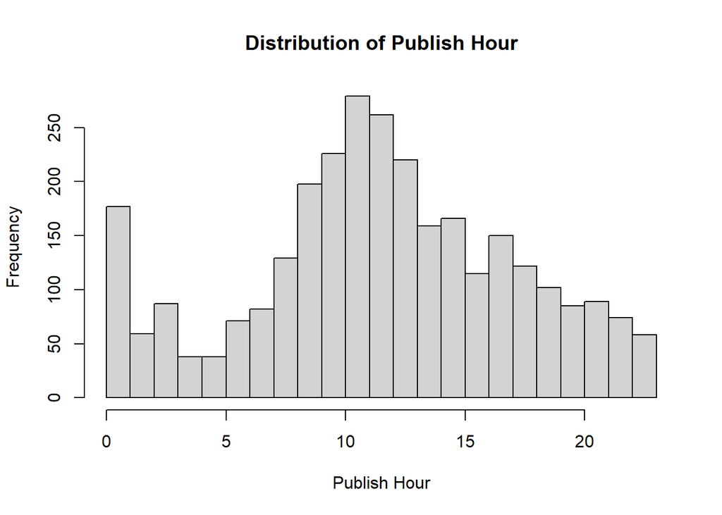

```r
hist(vids.u$publish_hour, breaks = 20, main = "Distribution of Publish Hour", xlab = "Publish Hour")
```

```r
# breaks untuk mengatur detail pemecahan kotak histogram dari data
```

Insight: * publish hour jam 10-12 paling tinggi masuk trending * ada indikasi bahwa data berdistribusi normal

### Boxplot

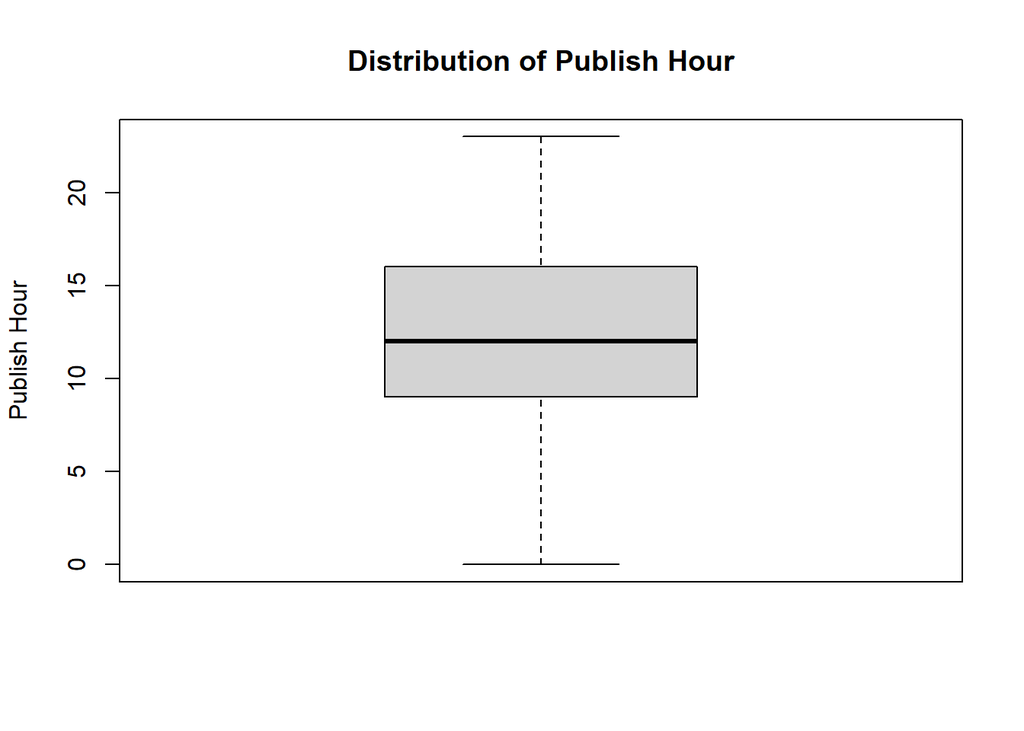

```r
boxplot(vids$publish_hour, main = "Distribution of Publish Hour", xlab = "", ylab = "Publish Hour")
```

Insight:

- tidak ada outlier
- ada indikasi berdistribusi normal, namun harus di test dulu

### `plot()`

`plot(x,y)`: Jenis plot yang dihasilkan berubah sesuai tipe data yang dimasukkan

- 1 variabel, x kategori: **bar chart**
- 1 variabel, x numerik: **scatter plot**
- 2 variabel, x dan y adalah numerik: **scatter plot**
- 2 variabel, x kategori, y numerik: **boxplot**

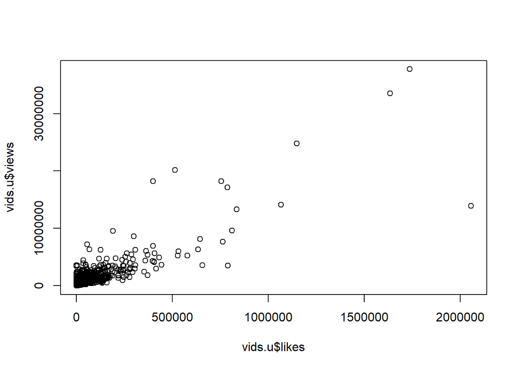

```r
plot(vids.u$likes, vids.u$views)
```

**Note:** Kita bisa tentukan tipe plot secara eksplisit di argumen `type =` pada `plot()`, namun perlu memperhatikan tipe plot yang tepat. Berikut [referensi](https://www.dummies.com/programming/r/how-to-create-different-plot-types-in-r/) untuk beragam type yang bisa dipakai.

**Business Question**

1. Apakah ada hubungan/pola tertentu antara `publish_hour` dengan `likes/views`?

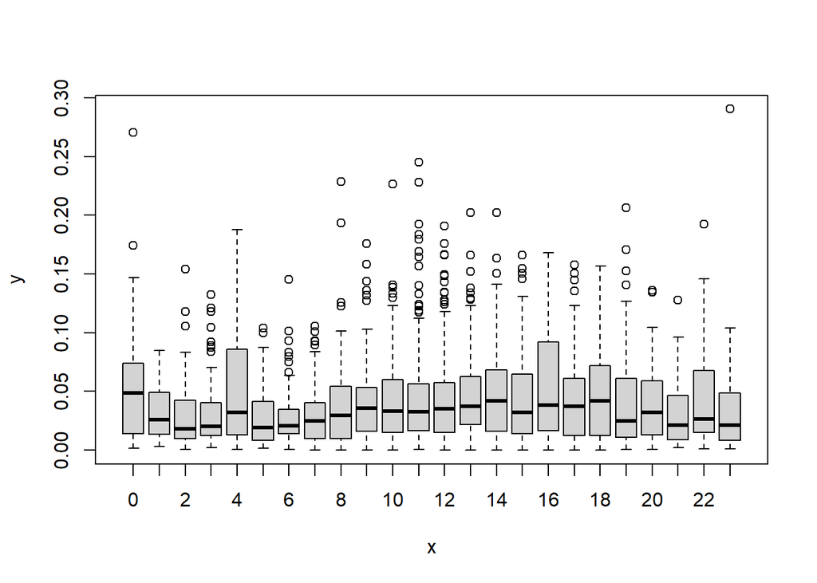

```r
# plot(x,y)
plot(as.factor(vids.u$publish_hour), vids.u$likes/vids.u$views)
```

Insight:

Tahapan:

```r
vids.agt <- vids.u[vids.u$category_id %in% c("Autos and Vehicles", "Gaming", "Travel and Events"), ]
vids.agt
```

|  | trending_date | title | channel_title | category_id | publish_time | views | likes | dislikes | comment_count | comments_disabled | ratings_disabled | video_error_or_removed | publish_hour | publish_when | publish_wday |
| --- | --- | --- | --- | --- | --- | --- | --- | --- | --- | --- | --- | --- | --- | --- | --- |
| 31 | 2017-11-14 | I TOOK THE $3,000,000 LAMBO TO CARMAX! They offered me...... | hp_overload | Autos and Vehicles | 2017-11-12 20:43:12 | 98378 | 4035 | 495 | 486 | FALSE | FALSE | FALSE | 20 | 4pm to 12am | Sunday |
| 35 | 2017-11-14 | New Emirates First Class Suite \| Boeing 777 \| Emirates | Emirates | Travel and Events | 2017-11-12 00:55:42 | 141148 | 1661 | 70 | 236 | FALSE | FALSE | FALSE | 0 | 12am to 8am | Sunday |
| 59 | 2017-11-14 | Train Swipes Parked Vehicle | ViralHog | Autos and Vehicles | 2017-11-12 19:46:11 | 7265 | 89 | 8 | 22 | FALSE | FALSE | FALSE | 19 | 4pm to 12am | Sunday |
| 132 | 2017-11-14 | L.A. Noire - Nintendo Switch Trailer | Nintendo | Gaming | 2017-11-09 14:59:48 | 154872 | 7683 | 164 | 1734 | FALSE | FALSE | FALSE | 14 | 8am to 4pm | Thursday |
| 164 | 2017-11-14 | Caterham Chris Hoy 60 Second Donut Challenge | Caterham Cars | Autos and Vehicles | 2017-11-09 04:59:31 | 4850 | 22 | 1 | 1 | FALSE | FALSE | FALSE | 4 | 12am to 8am | Thursday |
| 198 | 2017-11-14 | Inside Keanu Reeves' Custom Motorcycle Shop \| WIRED | WIRED | Autos and Vehicles | 2017-11-08 10:00:27 | 704363 | 16352 | 224 | 841 | FALSE | FALSE | FALSE | 10 | 8am to 4pm | Wednesday |
| 274 | 2017-11-15 | Evolution of the Jeep 4x4 Utility Vehicle \| Donut Media | Donut Media | Autos and Vehicles | 2017-11-13 10:00:05 | 93829 | 2229 | 36 | 469 | FALSE | FALSE | FALSE | 10 | 8am to 4pm | Monday |
| 292 | 2017-11-15 | 'Lightning Strike' B777-300 on departure @ KL743 // PH-BVS | Valk Aviation | Travel and Events | 2017-11-13 04:21:27 | 571588 | 386 | 47 | 113 | FALSE | FALSE | FALSE | 4 | 12am to 8am | Monday |
| 406 | 2017-11-16 | Our First Date | iHasCupquake | Gaming | 2017-11-15 15:00:00 | 224426 | 17784 | 225 | 2762 | FALSE | FALSE | FALSE | 15 | 8am to 4pm | Wednesday |
| 542 | 2017-11-16 | Vostok Brompton Beach Ride | Vostok.bike | Travel and Events | 2017-10-21 11:12:53 | 1118 | 6 | 0 | 2 | FALSE | FALSE | FALSE | 11 | 8am to 4pm | Saturday |

[output cut: 95 more lines]

2. buat kolom `likesp` berisi likes/view dan `dislikesp` berisi dislikes/view:

```r
vids.agt$likesp <- vids.agt$likes/vids.agt$views
vids.agt$dislikesp <- vids.agt$dislikes/vids.agt$views
```

additional cleaning (menghilangkan level yang tak ada pada data):

```r
levels(vids.agt$category_id)
```

```
#>  [1] "Autos and Vehicles"     "Comedy"                 "Education"
#>  [4] "Entertainment"          "Film and Animation"     "Gaming"
#>  [7] "Howto and Style"        "Music"                  "News and Politics"
#> [10] "Nonprofit and Activism" "People and Blogs"       "Pets and Animals"
#> [13] "Science and Technology" "Shows"                  "Sports"
#> [16] "Travel and Events"
```

```r
vids.agt$category_id <- droplevels(vids.agt$category_id)
```

3. visualisasikan:

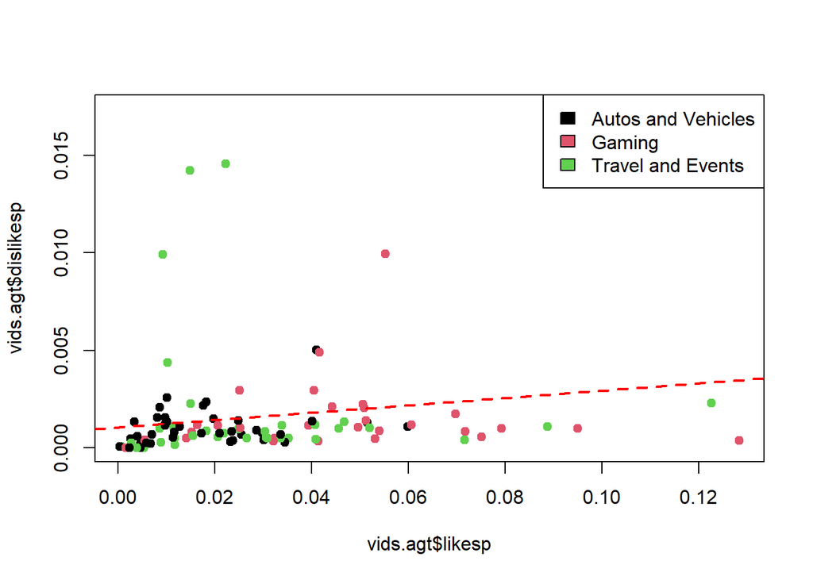

```r
plot(vids.agt$likesp, vids.agt$dislikesp, col=vids.agt$category_id, pch=19)
abline(lm(vids.agt$dislikesp ~ vids.agt$likesp), col= "red", lwd=2, lty=2)
legend("topright", legend=levels(vids.agt$category_id), fill=1:3)
```

Insight:

- korelasi likes/view dan dislikes/view positif lemah
- video dari category “Autos and Vehicle” memiliki likes/view dan dislikes/view yang cenderung rendah dibanding yang lain

**Dive Deeper**:

Joe adalah seorang YouTuber baru yang ambisius. Ia ingin membuat konten video yang dapat trending dan juga disukai oleh banyak orang. Berdasarkan data `vids.u`, konten dengan kategori apa yang memiliki likes/view paling baik sehingga dapat meningkatkan pamor channelnya? Bantu Joe untuk memecahkan masalahnya!

Tahapan:

- memakai data apa? `vids.u`
- kolom nya apakah sudah ada? belum, butuh informasi `likes/view`. bisa buat kolom baru / langsung diplotkan
- buat visualisasi menggunakan `plot()`!

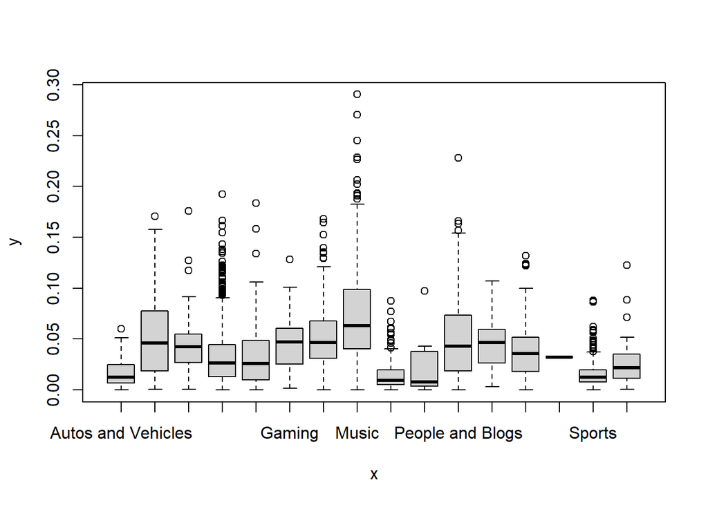

```r
# your code here
plot(vids.u$category_id, vids.u$likes/vids.u$views)
```

Insight: Music memiliki likes/view paling tinggi sehingga potensial untuk meningkatkan pamor channel. Joe dapat memilih kategori Music

**Summary Day 1**

- Flow Data Visualisasi:
  - Start Business Question
  - Prepare the data -> Read Data + Data Wrangling
  - Visualisasi
- Data Wrangling:
  - `lubridate`: package yang memudahkan kita untuk mengolah data tanggal dan waktu
  - feature engineering: membuat kolom/variable baru dari data yang ada
  - data wrangling dilakukan sesuai kebutuhan
- Base plot:
  - untuk exploratory data analysis (EDA)
  - dengan fungsi `plot()` dapat membuat beragam plot sesuai data yang dimasukkan.
  - visualisasinya masih sederhana
  - untuk mempercantik plot, codenya sulit dipahami dan mengharuskan user untuk menuliskan fungsi secara berurutan dan menjalankannya secara bersamaan sehingga tidak fleksibel
- Tipe-tipe plot:
  - histogram: melihat distribusi data numerik
  - barchart: frekuensi data kategorik
  - boxplot:
    - melihat distribusi data, summary statistics, dan outlier
    - distribusi data numerik untuk tiap kategori
  - scatterplot: melihat korelasi antar data
  - line: melihat trend (ada unsur waktu)

## `ggplot2`

Dikembangkan oleh Hadley Wickham (2005) dimana sistem pembuatan grafiknya **layer-by-layer**. Sistem tersebut lebih mudah untuk kostumisasi plot sehingga digunakan untuk **explanatory data analysis** atau visualisasi yang ditujukan untuk audiens.

```r
# install.packages("ggplot2")
library(ggplot2)
```

formula:

`ggplot(data, mapping = aes(x,y, ...)) + geom_* + dst`

1. Sebagai seorang YouTuber, kita ingin memiliki video dengan likeability (likes/view) yang tinggi, dan enggagement (comments/view) yang tinggi. Dari data `vids.agt`, manakah kategori yang paling baik untuk dibuatkan konten?

Tahapan:

1. Siapkan data:

```r
# buat kolom commentp (comment/view)
vids.agt$commentp <- vids.agt$comment_count/vids.agt$views

# cek data
head(vids.agt)
```

|  | trending_date | title | channel_title | category_id | publish_time | views | likes | dislikes | comment_count | comments_disabled | ratings_disabled | video_error_or_removed | publish_hour | publish_when | publish_wday | likesp | dislikesp | commentp |
| --- | --- | --- | --- | --- | --- | --- | --- | --- | --- | --- | --- | --- | --- | --- | --- | --- | --- | --- |
| 31 | 2017-11-14 | I TOOK THE $3,000,000 LAMBO TO CARMAX! They offered me...... | hp_overload | Autos and Vehicles | 2017-11-12 20:43:12 | 98378 | 4035 | 495 | 486 | FALSE | FALSE | FALSE | 20 | 4pm to 12am | Sunday | 0.041015268 | 0.0050316128 | 0.0049401289 |
| 35 | 2017-11-14 | New Emirates First Class Suite \| Boeing 777 \| Emirates | Emirates | Travel and Events | 2017-11-12 00:55:42 | 141148 | 1661 | 70 | 236 | FALSE | FALSE | FALSE | 0 | 12am to 8am | Sunday | 0.011767790 | 0.0004959333 | 0.0016720039 |
| 59 | 2017-11-14 | Train Swipes Parked Vehicle | ViralHog | Autos and Vehicles | 2017-11-12 19:46:11 | 7265 | 89 | 8 | 22 | FALSE | FALSE | FALSE | 19 | 4pm to 12am | Sunday | 0.012250516 | 0.0011011700 | 0.0030282175 |
| 132 | 2017-11-14 | L.A. Noire - Nintendo Switch Trailer | Nintendo | Gaming | 2017-11-09 14:59:48 | 154872 | 7683 | 164 | 1734 | FALSE | FALSE | FALSE | 14 | 8am to 4pm | Thursday | 0.049608709 | 0.0010589390 | 0.0111963428 |
| 164 | 2017-11-14 | Caterham Chris Hoy 60 Second Donut Challenge | Caterham Cars | Autos and Vehicles | 2017-11-09 04:59:31 | 4850 | 22 | 1 | 1 | FALSE | FALSE | FALSE | 4 | 12am to 8am | Thursday | 0.004536082 | 0.0002061856 | 0.0002061856 |
| 198 | 2017-11-14 | Inside Keanu Reeves' Custom Motorcycle Shop \| WIRED | WIRED | Autos and Vehicles | 2017-11-08 10:00:27 | 704363 | 16352 | 224 | 841 | FALSE | FALSE | FALSE | 10 | 8am to 4pm | Wednesday | 0.023215302 | 0.0003180178 | 0.0011939866 |

2. Visualisasi data:

x = category_id y = likesp

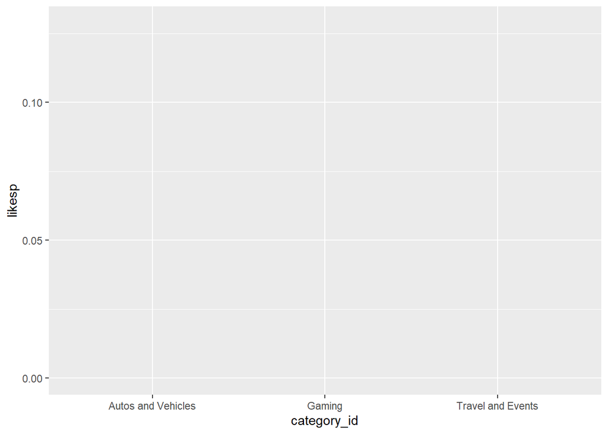

```r
# main layer
ggplot(data = vids.agt, mapping = aes(x = category_id, y = likesp))
```

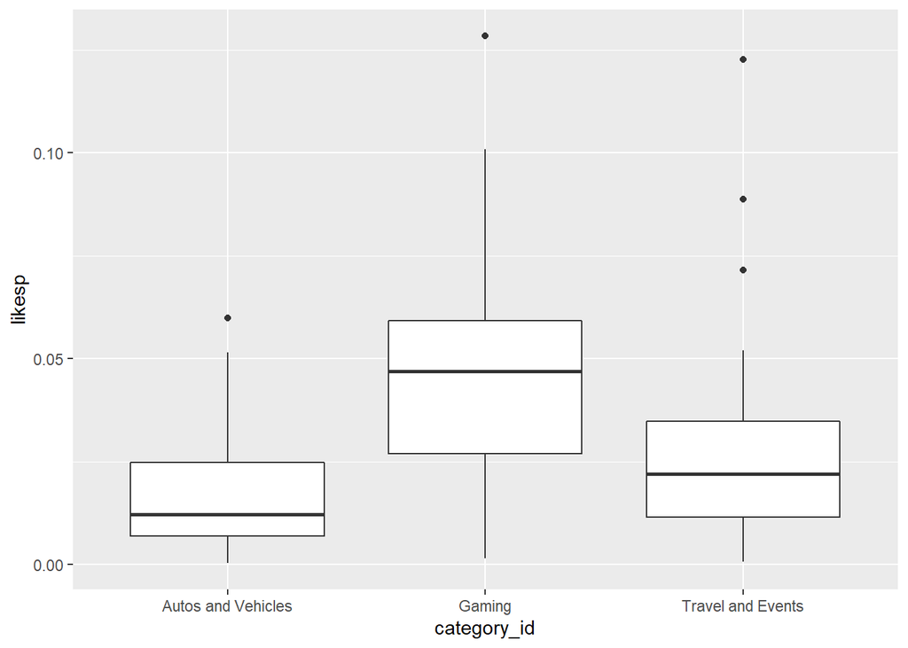

```r
# layer 1: boxplot
ggplot(data = vids.agt, mapping = aes(x = category_id, y = likesp)) +
  geom_boxplot()
```

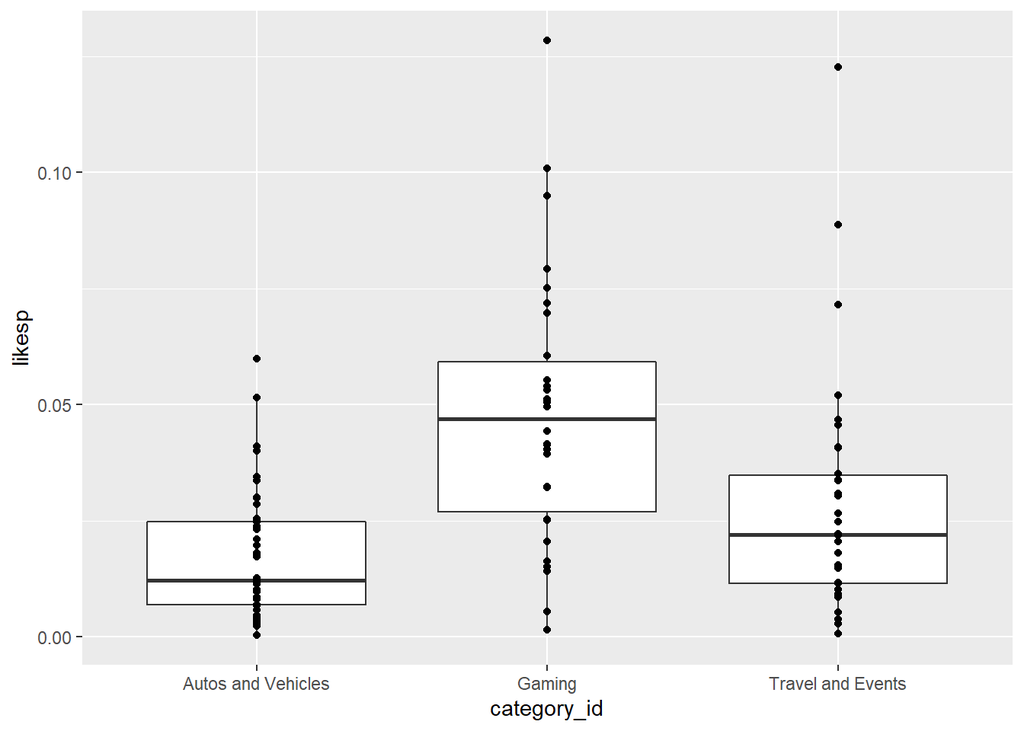

```r
# layer 2: scatterplot
ggplot(data = vids.agt, mapping = aes(x = category_id, y = likesp)) +
  geom_boxplot() +
  geom_point()
```

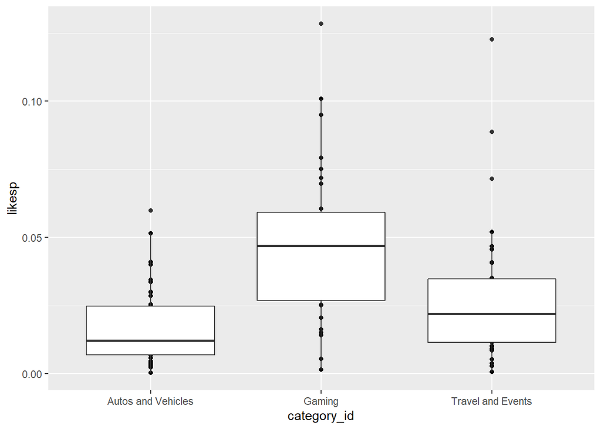

```r
# urutan code ggplot amat berpengaruh ke tampilan, layer terakhir akan menimpa layer sebelumnya
ggplot(data = vids.agt, mapping = aes(x = category_id, y = likesp)) + # layer 1
  geom_point() + # layer 2
  geom_boxplot() # layer 3
```

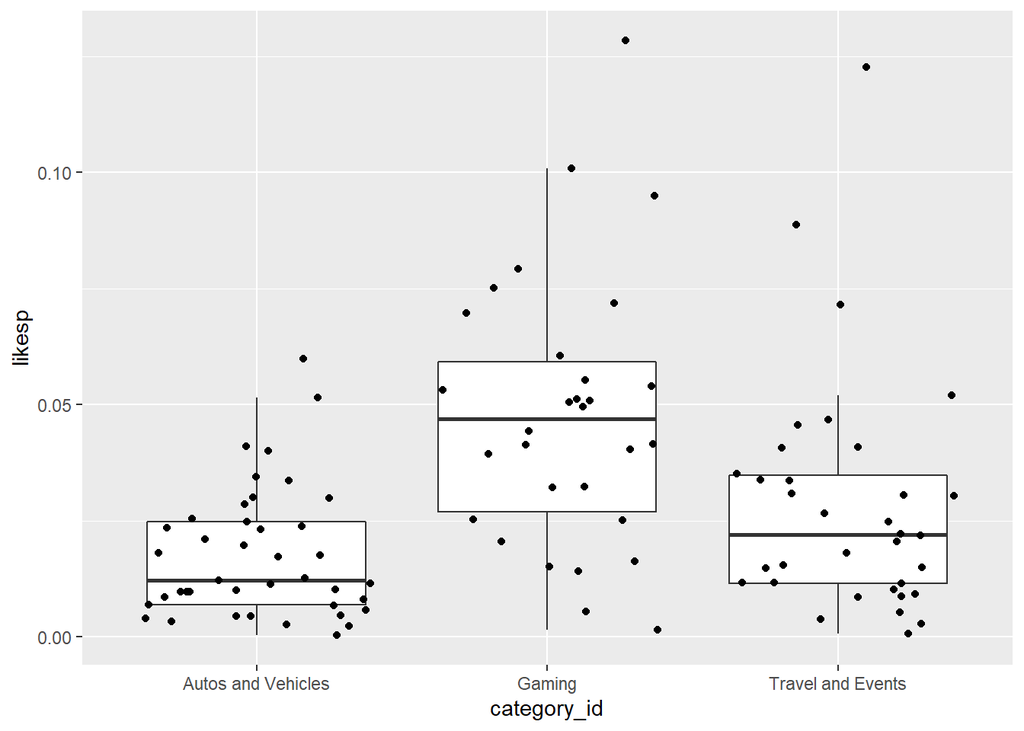

```r
# geom_point -> geom_jitter
ggplot(data = vids.agt, mapping = aes(x = category_id, y = likesp)) +
    geom_boxplot(outlier.shape = NA) + # outlier tidak ditampilkan karena sudah diplotkan oleh geom_jitter
    geom_jitter() # scatterplot dengan titik yang random bergeser ke kiri/kanan, agar tidak tumpang tindih
```

Mengatur aesthetic berdasarkan/tidak berdasarkan data:

Mengatur size `geom_jitter` berdasarkan `comment/view` (berdasarkan data):

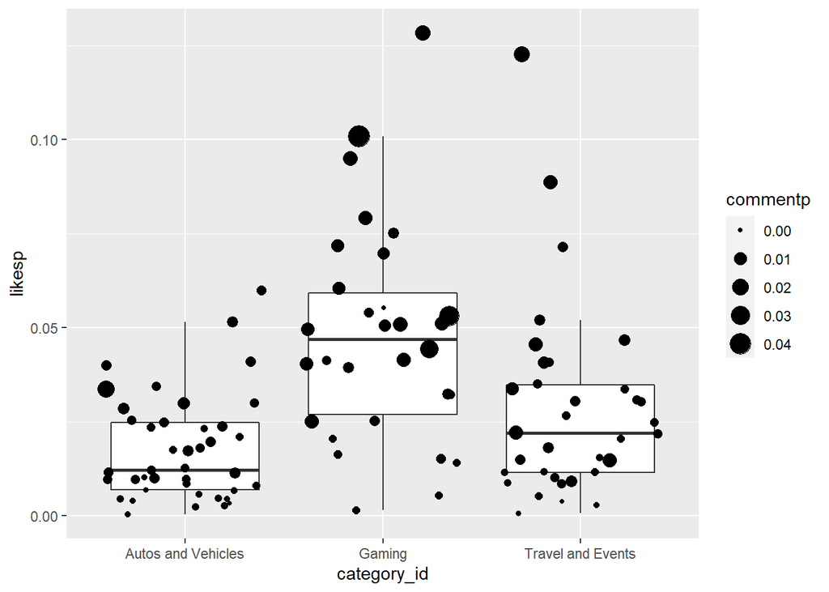

```r
# masukan parameter di dalam aes() bila berdasarkan data
ggplot(data = vids.agt, mapping = aes(x = category_id, y = likesp)) +
    geom_boxplot(outlier.shape = NA) +
    geom_jitter(mapping = aes(size = commentp))
```

Mengatur size `geom_jitter` tidak berdasarkan data:

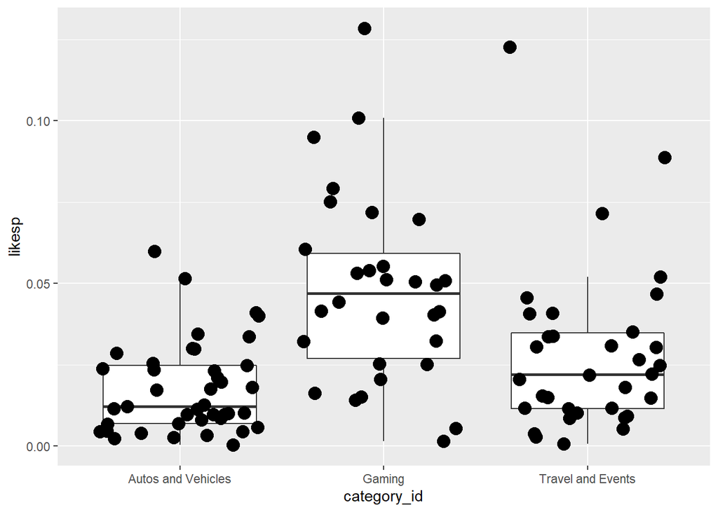

```r
# masukan parameter di luar aes() bila tidak berdasarkan data
ggplot(data = vids.agt, mapping = aes(x = category_id, y = likesp)) +
    geom_boxplot(outlier.shape = NA) +
    geom_jitter(size = 4) # size tidak berdasarkan data; seragam 4
```

Mewarnai plot agar lebih menarik:

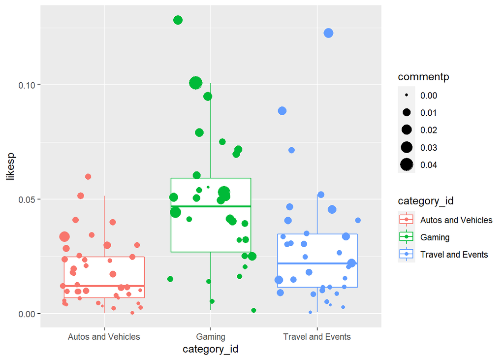

```r
# col di dalam `ggplot()` akan mewarnai semua geom
# apapun yang di set dalam fungsi `ggplot()` akan diaplikasikan ke layer berikutnya
ggplot(data = vids.agt, mapping = aes(x = category_id, y = likesp, color = category_id)) +
    geom_boxplot(outlier.shape = NA) +
    geom_jitter(mapping = aes(size = commentp))
```

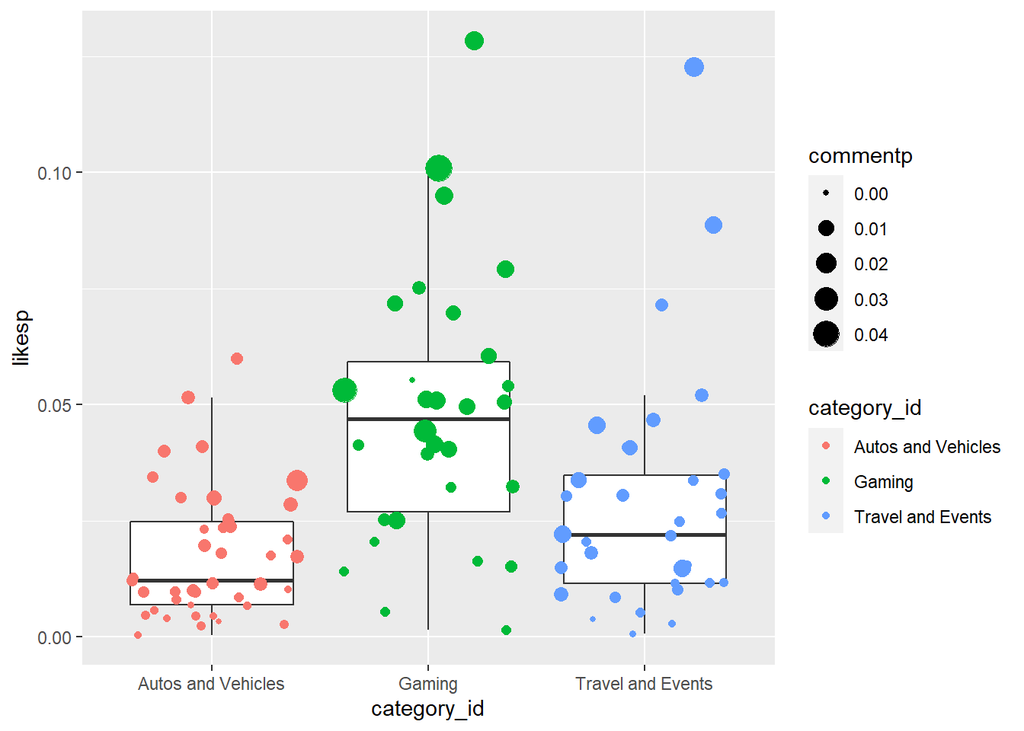

```r
# col di dalam geom hanya mewarnai geom tersebut
ggplot(data = vids.agt, mapping = aes(x = category_id, y = likesp)) +
    geom_boxplot(outlier.shape = NA) +
    geom_jitter(mapping = aes(size = commentp, color = category_id))
```

Pewarnaan menggunakan `col`/`color` vs `fill`:

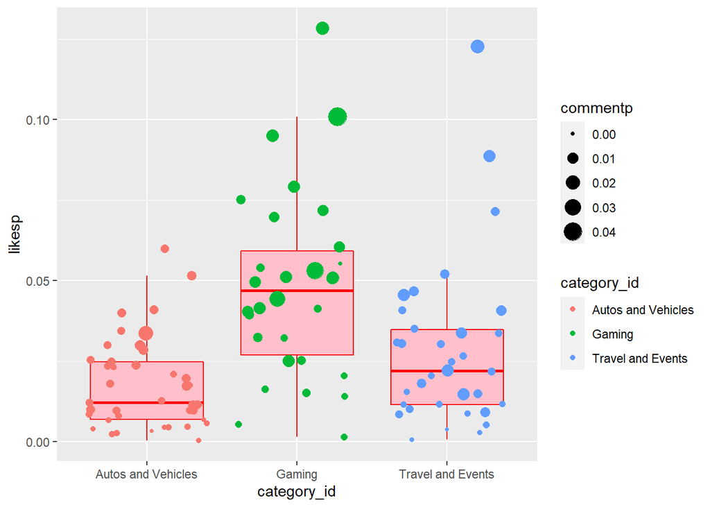

```r
# fill untuk mewarnai area (bagian dalam shape)
# col untuk mewarnai garis (border/line/point)

ggplot(data = vids.agt, mapping = aes(x = category_id, y = likesp)) +
    geom_boxplot(outlier.shape = NA, fill = "pink", col = "red") +
    geom_jitter(mapping = aes(size = commentp, color = category_id))
```

**Note:** Kita telah memahami cara pembuatan plot di ggplot2. Selanjutnya kita juga perlu memperhatikan tampilan plot. Plot yang terlalu rumit justru dapat membuyarkan fokus dari informasi yang ingin disampaikan. Contoh, kita tidak perlu mewarnai `geom_jitter` berdasarkan `category_id` karena perbedaan `category_id` sudah dijelaskan di x-axis.

**Dive Deeper**:

Percantik Plot! Untuk membuat **plot yang informatif, minimalis, dan apik!**, lengkapi code di bawah agar terbentuk plot dengan spesifikasi berikut:

- x = category_id
- y = likesp
- size geom_jitter = commentp
- warna area boxplot = “black”
- warna line boxplot = “red”
- warna geom_jitter = “red”

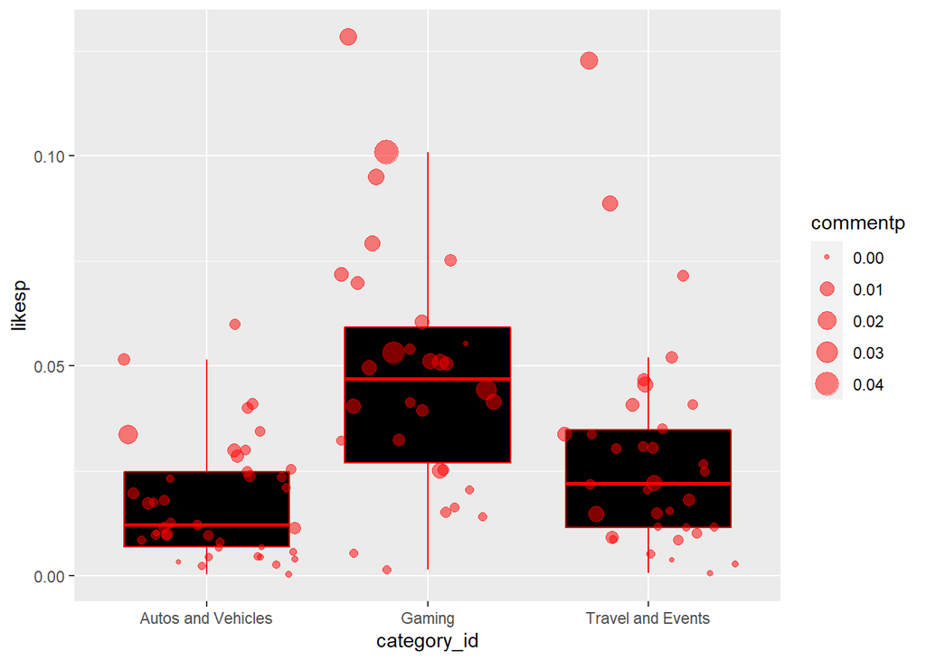

```r
# buat plot
g <- ggplot(data = vids.agt, mapping = aes(x = category_id, y = likesp)) +
  geom_boxplot(outlier.shape = NA, fill = "black", col = "red") +
  geom_jitter(mapping = aes(size = commentp), col = "red",
              alpha = 0.5) # aes u/ mengatur transparansi warna

g
```

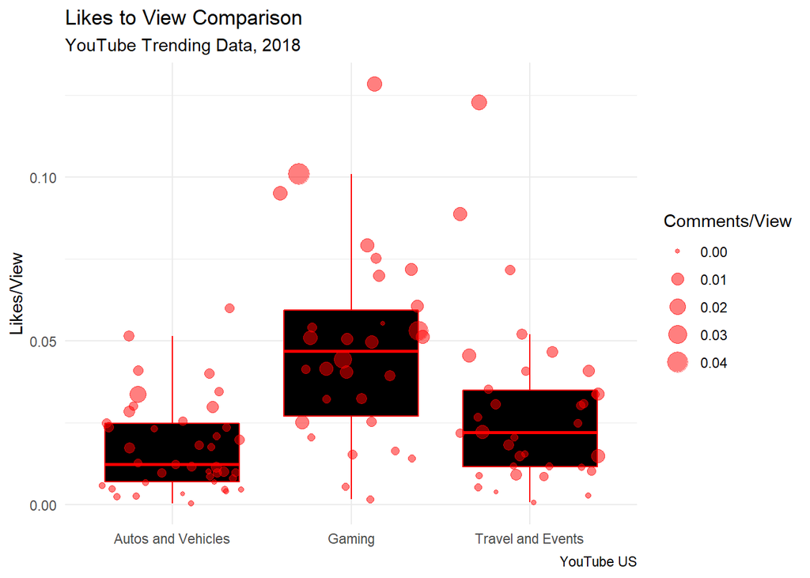

```r
# finalisasi plot dengan label & tema
g + labs(title = "Likes to View Comparison",
       subtitle = "YouTube Trending Data, 2018",
       x = NULL,
       y = "Likes/View",
       caption = "YouTube US",
       size = "Comments/View") + # mengatur nama legend untuk aesthetic size
  theme_minimal() # tema bawaan di ggplot2
```

Insight:

- Video dengan likes/view paling tinggi ada di kategori Gaming
- Engagement rate (comment/view) kategori gaming juga secara umum lebih tinggi dibanding kategori lain.
- Kategori gaming baik untuk dibuatkan konten video

**Important Points:**

- **ggplot2** bekerja *layer-by-layer*, layer pertama akan ditimpa oleh layer berikutnya.
- `geom_*`: untuk menambahkan elemen geometrik pada plot (tipe plot):
  - `geom_boxplot()`: boxplot
  - `geom_point()`: scatterplot
  - `geom_jitter()`: scatterplot (dengan titik yang randomly scattered ke kiri/kanan)
  - `labs()`: label seperti title, subtitle, y-axis & x-axis label, dll
- Beberapa parameter *aesthetic* (elemen visual) untuk plot:
  - x: sumbu x -> berdasarkan data
  - y: sumbu y -> berdasarkan data
  - size: ukuran
  - col/color: mewarnai garis/titik
  - fill: mewarnai area
  - alpha: transparansi
- untuk mengatur aesthetic **berdasarkan data**, masukan **di dalam** `aes()`.
- untuk mengatur aesthetic untuk semua geom, masukan `aes()` di dalam `ggplot()`

## Top Channel in Trending Videos

Sebagai Plan B, kita juga berencana untuk kolaborasi dengan channel YouTube yang sering muncul dalam pencarian video trending! Adakah channel YouTube yang memiliki **lebih dari sama dengan 10 video trending**? Channel YouTube mana yang baik untuk jadi rekan kolaborasi?

Tahapan:

1. Siapkan data

```r
head(vids.u)
```

|  | trending_date | title | channel_title | category_id | publish_time | views | likes | dislikes | comment_count | comments_disabled | ratings_disabled | video_error_or_removed | publish_hour | publish_when | publish_wday |
| --- | --- | --- | --- | --- | --- | --- | --- | --- | --- | --- | --- | --- | --- | --- | --- |
| 1 | 2017-11-14 | WE WANT TO TALK ABOUT OUR MARRIAGE | CaseyNeistat | People and Blogs | 2017-11-13 12:13:01 | 748374 | 57527 | 2966 | 15954 | FALSE | FALSE | FALSE | 12 | 8am to 4pm | Monday |
| 2 | 2017-11-14 | The Trump Presidency: Last Week Tonight with John Oliver (HBO) | LastWeekTonight | Entertainment | 2017-11-13 02:30:00 | 2418783 | 97185 | 6146 | 12703 | FALSE | FALSE | FALSE | 2 | 12am to 8am | Monday |
| 3 | 2017-11-14 | Racist Superman \| Rudy Mancuso, King Bach & Lele Pons | Rudy Mancuso | Comedy | 2017-11-12 14:05:24 | 3191434 | 146033 | 5339 | 8181 | FALSE | FALSE | FALSE | 14 | 8am to 4pm | Sunday |
| 4 | 2017-11-14 | Nickelback Lyrics: Real or Fake? | Good Mythical Morning | Entertainment | 2017-11-13 06:00:04 | 343168 | 10172 | 666 | 2146 | FALSE | FALSE | FALSE | 6 | 12am to 8am | Monday |
| 5 | 2017-11-14 | I Dare You: GOING BALD!? | nigahiga | Entertainment | 2017-11-12 13:01:41 | 2095731 | 132235 | 1989 | 17518 | FALSE | FALSE | FALSE | 13 | 8am to 4pm | Sunday |
| 6 | 2017-11-14 | 2 Weeks with iPhone X | iJustine | Science and Technology | 2017-11-13 14:07:23 | 119180 | 9763 | 511 | 1434 | FALSE | FALSE | FALSE | 14 | 8am to 4pm | Monday |

```r
# buat data frame
vids.chan <- as.data.frame(table(vids.u$channel_title))
head(vids.chan)
```

|  | Var1 | Freq |
| --- | --- | --- |
| 1 | _¢_Á_\235 | 1 |
| 2 | “÷\201\220µ_‘â¬“_\220 Korean Englishman | 1 |
| 3 | ‹Äø‹Ä_‹Ä_‹Ä_ ‹ÄÐ‹Ä©‹â¦‹Ä_‹â_ ŒÉÂŒ_\217‹Ä\201‹Ä£‹Ä_‹Ä\215‹ÄÇ | 1 |
| 4 | 12 News | 1 |
| 5 | 1theK (“Ý\220‘\215Ó“_Û“\235«) | 5 |
| 6 | 20th Century Fox | 9 |

```r
# filter channel dengan kemunculan video trending >= 10
vids.chan <- vids.chan[vids.chan$Freq >= 10,]
head(vids.chan)
```

|  | Var1 | Freq |
| --- | --- | --- |
| 94 | BBC News | 13 |
| 172 | BuzzFeedVideo | 10 |
| 253 | CNN | 17 |
| 262 | CollegeHumor | 15 |
| 263 | ColliderVideos | 13 |
| 359 | E! Entertainment | 13 |

```r
# urutkan data
vids.chan <- vids.chan[order(vids.chan$Freq, decreasing = T),]
head(vids.chan)
```

|  | Var1 | Freq |
| --- | --- | --- |
| 1019 | Refinery29 | 31 |
| 1226 | The Tonight Show Starring Jimmy Fallon | 30 |
| 1354 | Vox | 29 |
| 1241 | TheEllenShow | 28 |
| 881 | Netflix | 27 |
| 889 | NFL | 25 |

2. Visualisasi data

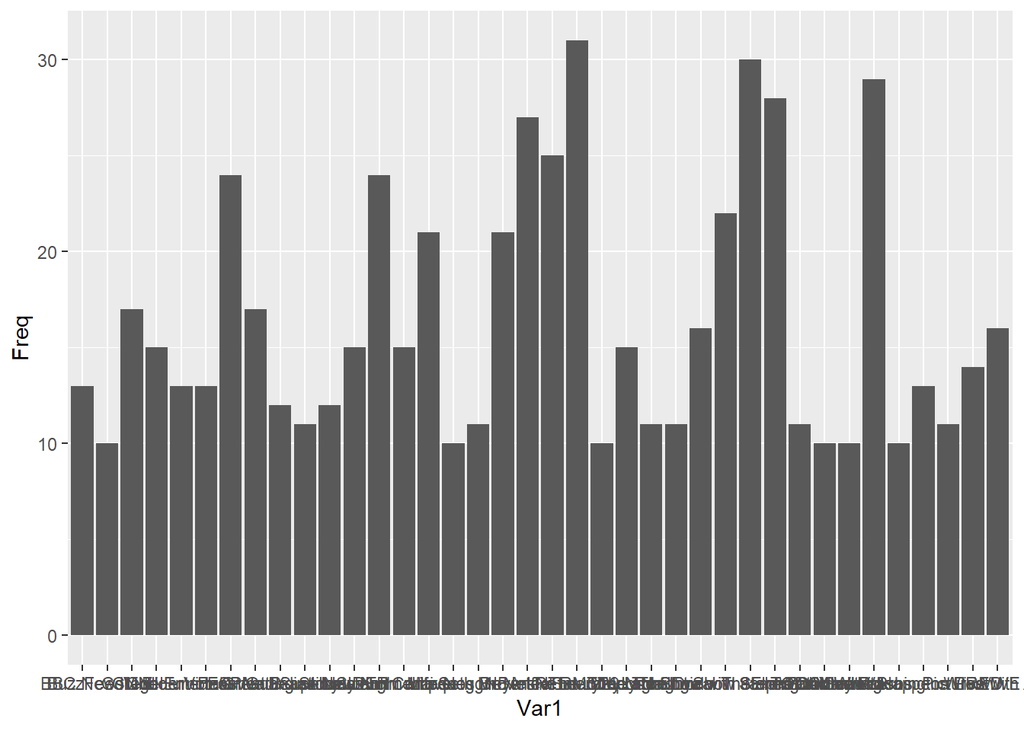

```r
# plot dasar
ggplot(data = vids.chan, mapping = aes(x = Var1, y = Freq)) +
  geom_col()
```

Task percantik plot:

- ubah angle pada x axis text

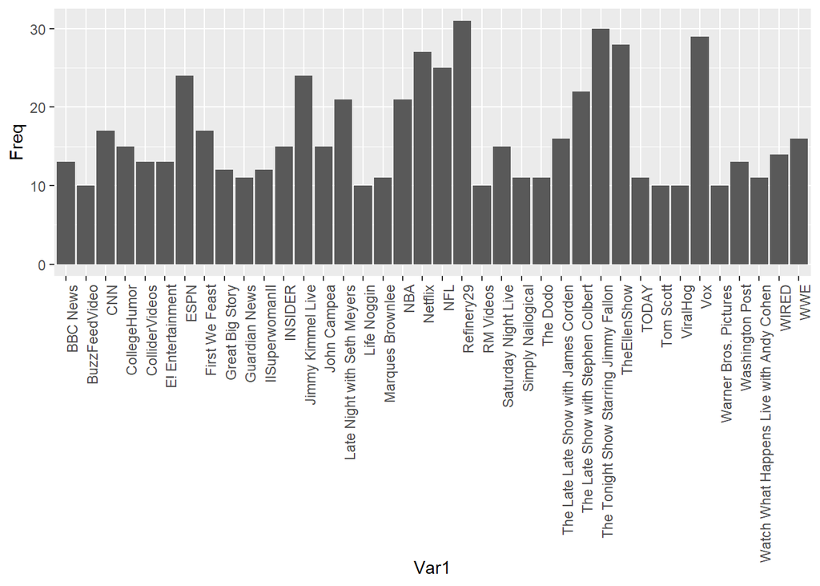

```r
ggplot(data = vids.chan, mapping = aes(x = Var1, y = Freq)) +
  geom_col() +
  theme(axis.text.x = element_text(angle = 90, # 90 derajat
                                   hjust = 1)) # horizontal just, agar text persis di sebelah tick marks
```

- flip koordinat x - y

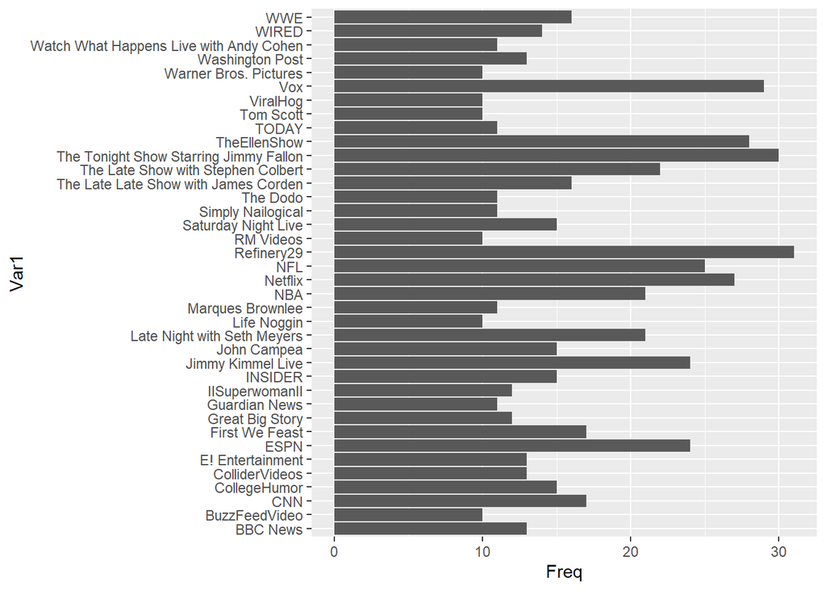

```r
ggplot(data = vids.chan, mapping = aes(x = Freq, y = Var1)) +
  geom_col()
```

- top 10 data

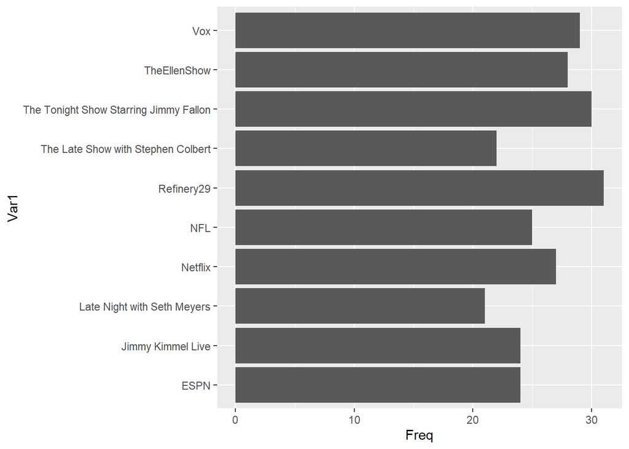

```r
ggplot(data = vids.chan[1:10,], # filter 10 data teratas
       mapping = aes(x = Freq, y = Var1)) +
  geom_col()
```

- urutannya diatur dari tertinggi ke terendah

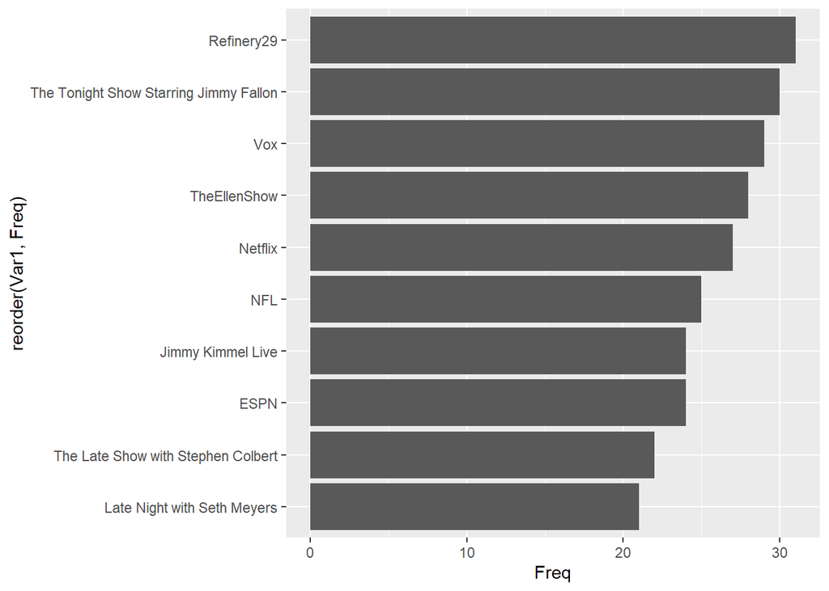

```r
ggplot(data = vids.chan[1:10,],
       mapping = aes(x = Freq,
                     y = reorder(Var1, Freq))) + # reorder Var1 (channel) berdasarkan Freq
  geom_col()
```

- menambahkan warna

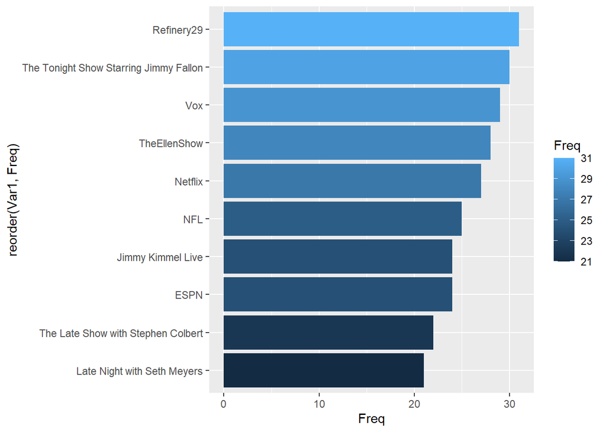

```r
ggplot(data = vids.chan[1:10,], mapping = aes(x = Freq, y = reorder(Var1, Freq))) +
  geom_col(mapping = aes(fill = Freq)) # warna otomatis gradient berdasarkan nilai Freq yang numerik
```

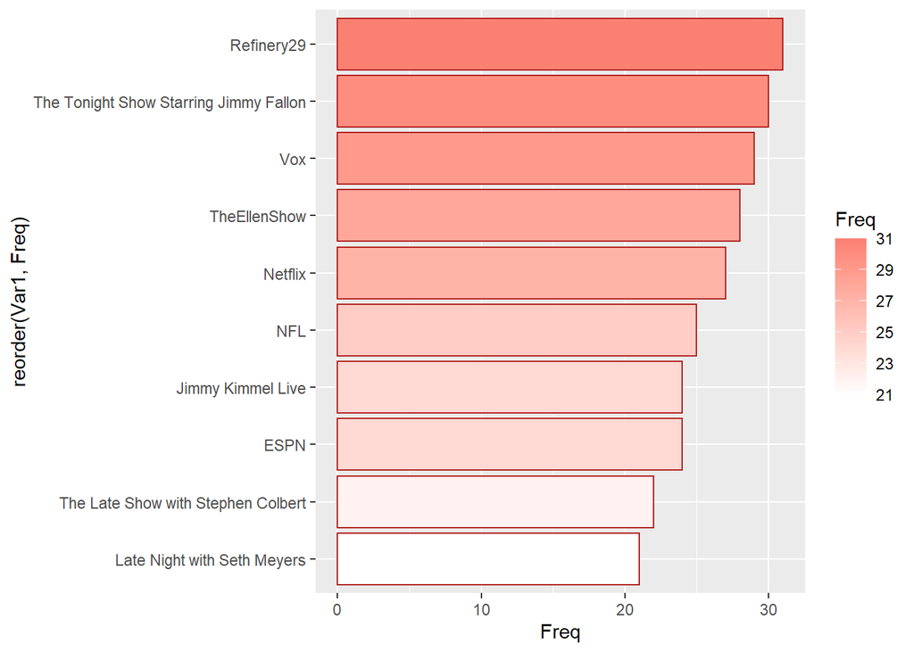

```r
ggplot(data = vids.chan[1:10,], mapping = aes(x = Freq, y = reorder(Var1, Freq))) +
  geom_col(mapping = aes(fill = Freq),
           col = "firebrick") + # mengatur border color
  scale_fill_gradient(low = "white", high = "salmon") # mengatur warna gradient manual
```

- kasih garis rata-rata

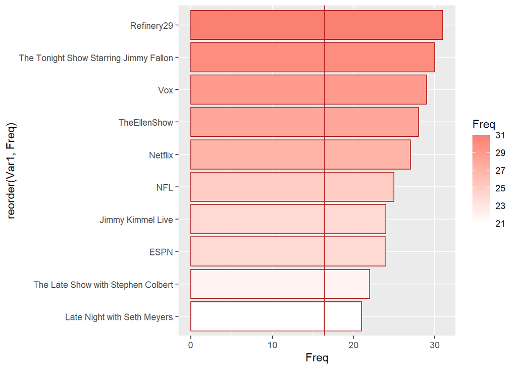

```r
ggplot(data = vids.chan[1:10,], mapping = aes(x = Freq, y = reorder(Var1, Freq))) +
  geom_col(mapping = aes(fill = Freq), col = "firebrick") +
  scale_fill_gradient(low = "white", high = "salmon") +
  geom_vline(xintercept = mean(vids.chan$Freq), # titik x nya
             col = "firebrick") # warna vertical line
```

- menambahkan text pada plot

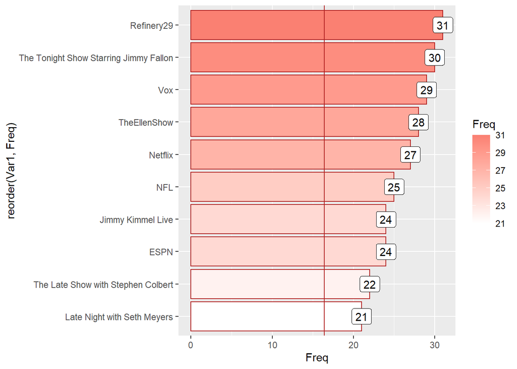

```r
# label: text yang ada background nya
ggplot(data = vids.chan[1:10,], mapping = aes(x = Freq, y = reorder(Var1, Freq))) +
  geom_col(mapping = aes(fill = Freq), col = "firebrick") +
  scale_fill_gradient(low = "white", high = "salmon") +
  geom_vline(xintercept = mean(vids.chan$Freq), col = "firebrick") +
  geom_label(aes(label = Freq)) # label berdasarkan data Freq
```

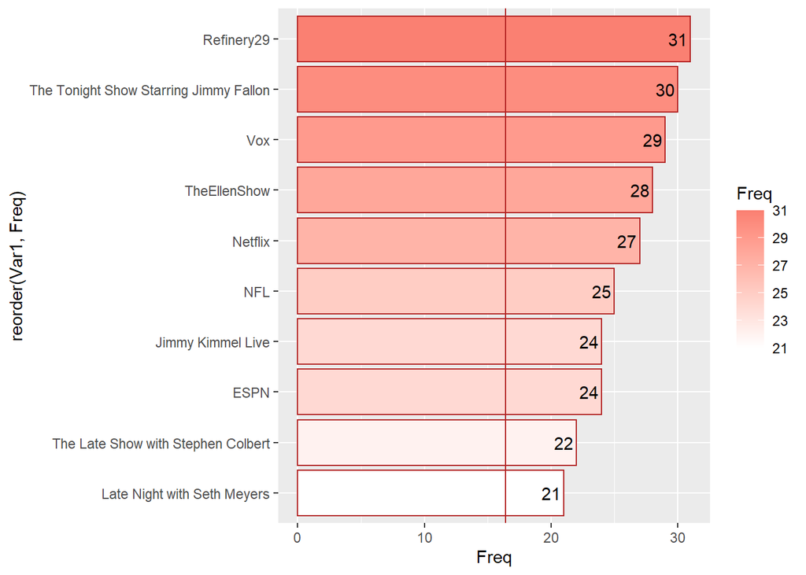

```r
# text: text tanpa background
ggplot(data = vids.chan[1:10,], mapping = aes(x = Freq, y = reorder(Var1, Freq))) +
  geom_col(mapping = aes(fill = Freq), col = "firebrick") +
  scale_fill_gradient(low = "white", high = "salmon") +
  geom_vline(xintercept = mean(vids.chan$Freq), col = "firebrick") +
  geom_text(aes(label = Freq),
            nudge_x = -1) # untuk menggeser text menjadi 1 poin ke arah kiri
```

- mengatur labs: kasih title, x & y axis title, dll

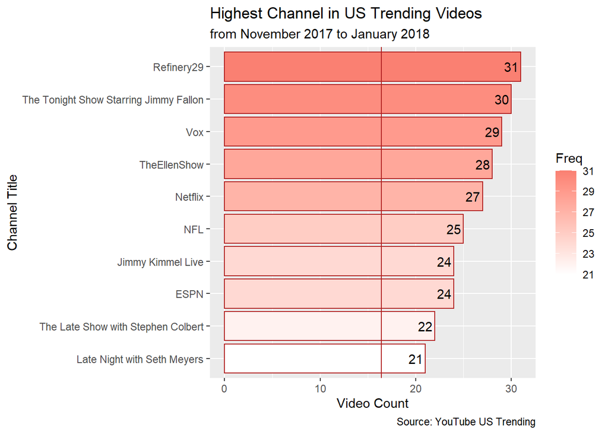

```r
ggplot(data = vids.chan[1:10,], mapping = aes(x = Freq, y = reorder(Var1, Freq))) +
  geom_col(mapping = aes(fill = Freq), col = "firebrick") +
  scale_fill_gradient(low = "white", high = "salmon") +
  geom_vline(xintercept = mean(vids.chan$Freq), col = "firebrick") +
  geom_text(aes(label = Freq), nudge_x = -1) +
  labs(title = "Highest Channel in US Trending Videos",
       subtitle = "from November 2017 to January 2018",
       x = "Video Count",
       y = "Channel Title", # untuk menghilangkan labs tertentu
       caption = "Source: YouTube US Trending") # biasanya diisi sumber data
```